# CalledStrike Package

Jim Albert

2/26/2019

Load the package. It assumes that the packages ggplot2, dplyr, baseballr, and mgcv have already been installed.

```r
library(CalledStrike)
```

#### Collect Data

Here we find the MLBAM id for Mike Trout. The get_sc_data() function (wrapper for the baseballr function) will download the Statcast data for Trout for the 2018 season.

```r
mt_id <- get_id("Mike Trout")
mt <- get_sc_data(mt_id, season = 2018)
```

#### Called Strikes

This constructs a tile plot for the probability that a called pitch is a strike.

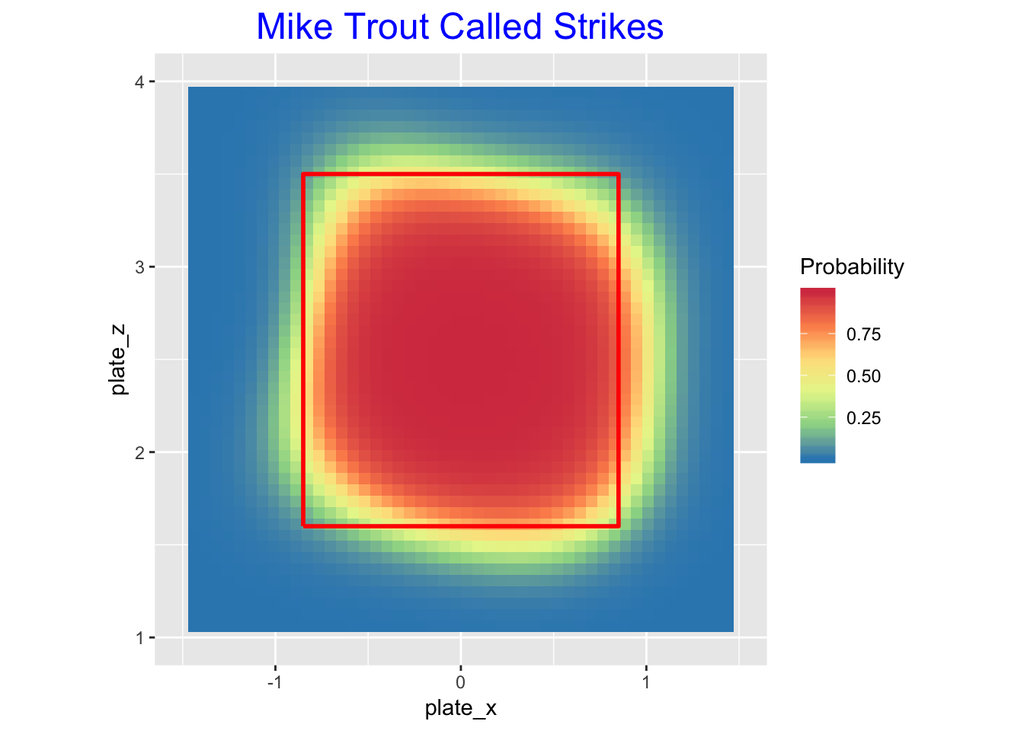

```r
called_strike_plot(mt, "Mike Trout Called Strikes")
```

#### Miss Swing Rates

Constructs a tile plot for the probability that Trout misses on a swing.

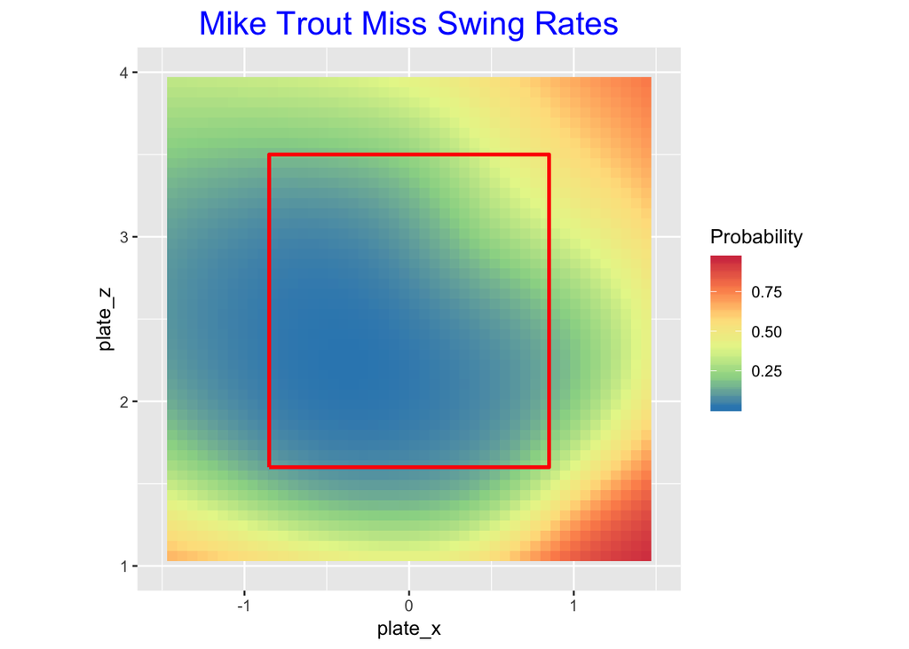

```r
miss_swing_plot(mt, "Mike Trout Miss Swing Rates")
```

#### Zones of Hits and Home Runs

Constructs a tile plot for the probability that Trout hits a home run on a ball in-play.

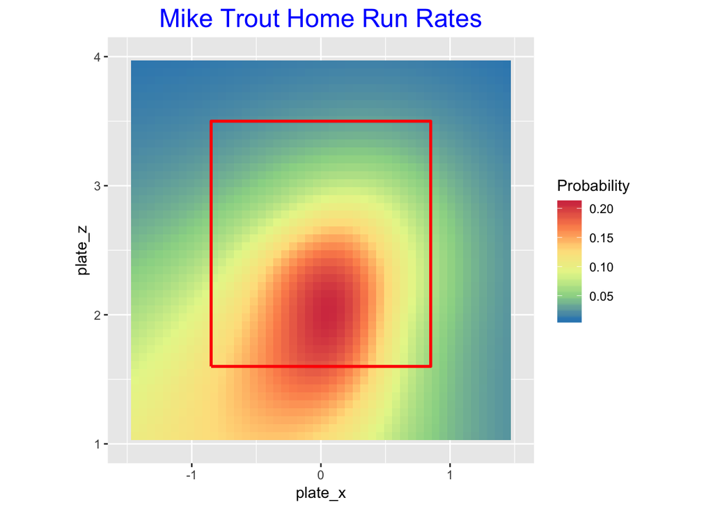

```r
home_run_plot(mt, "Mike Trout Home Run Rates")
```

Constructs a tile plot for the probability that Trout gets a hit on a ball in-play.

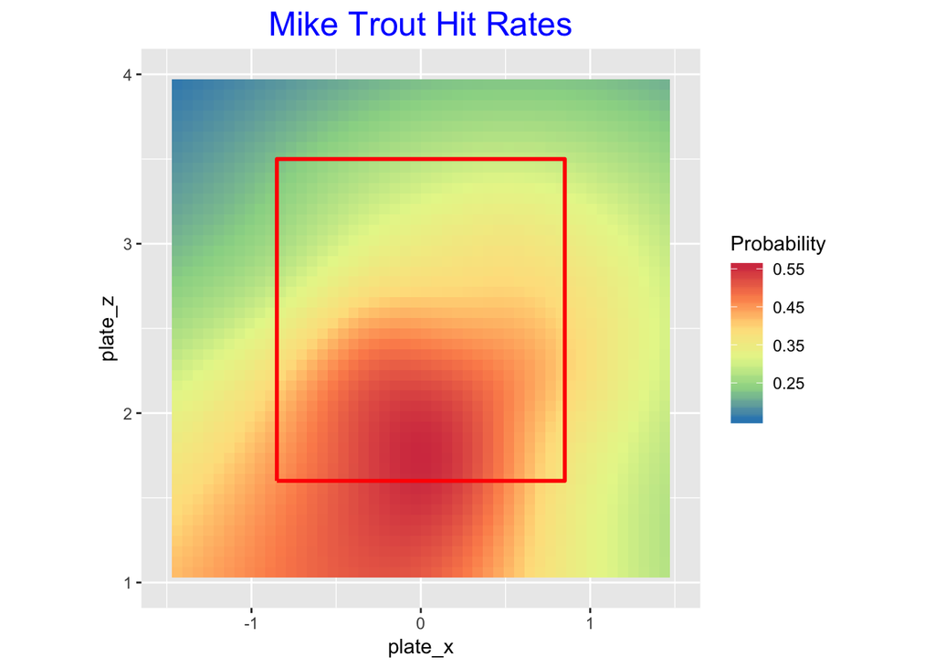

```r
hit_plot(mt, "Mike Trout Hit Rates")
```

#### Statcast Variables (launch speed, launch angle, spray angle)

Constructs a tile plot for the launch speed on a ball in-play.

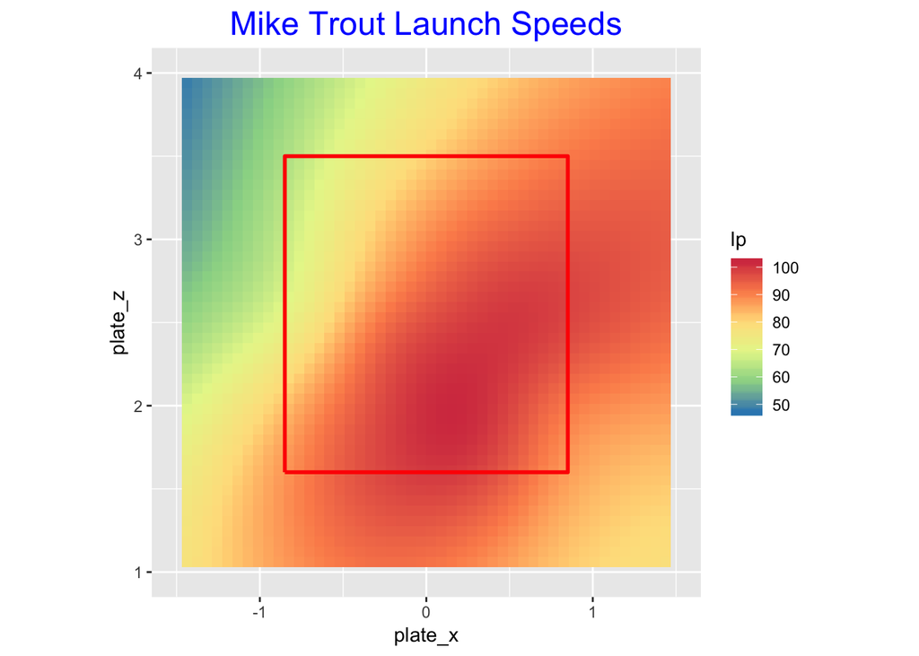

```r
ls_plot(mt, "Mike Trout Launch Speeds")
```

Constructs a tile plot for the launch angle on a ball in-play.

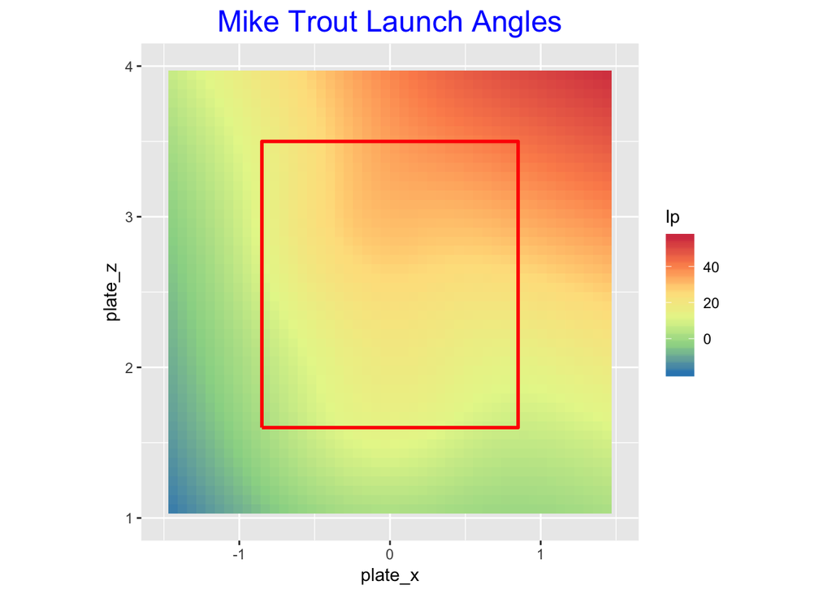

```r
la_plot(mt, "Mike Trout Launch Angles")
```

Constructs a tile plot for the spray angle on a ball in-play.

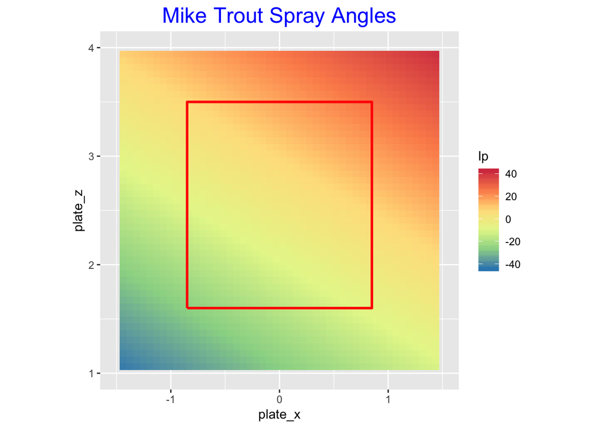

```r
sa_plot(mt, "Mike Trout Spray Angles")
```

#### Contour Plots

The wrapper functions above all use tile plots, but these can be drawn using contour plots where one inputs the value for the contour lines.

Here is a contour plot version of Trout’s in-play hit rates.

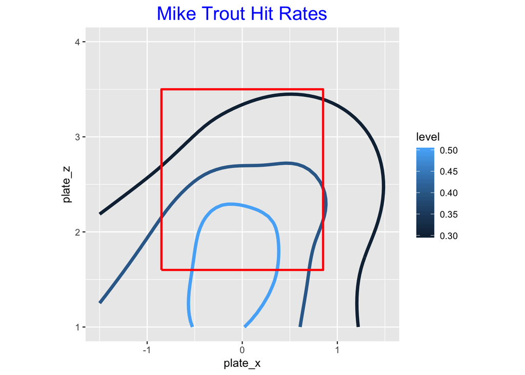

```r
mt %>%
    setup_inplay() %>%
    hr_h_gam_fit(HR = FALSE) %>%
    contour_plot_p(P = c(0.3, 0.4, 0.5)) +
    ggtitle("Mike Trout Hit Rates") +
    centertitle()
```

Here is a contour plot version of Trout’s in-play launch speeds.

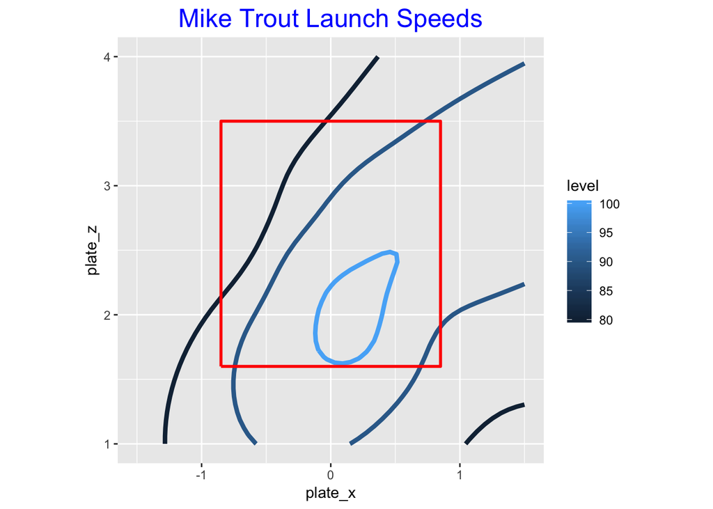

```r
mt %>%
    setup_inplay() %>%
    ls_gam_fit() %>%
    contour_plot_m(M = c(80, 90, 100)) +
    ggtitle("Mike Trout Launch Speeds") +
    centertitle()
```

#### Comparison of Two Groups

Let’s compare Trout’s performance for the 2017 and 2018 seasons.

First collect data for the two seasons:

```r
mt_17 <- get_sc_data(mt_id, season = 2017)
mt_18 <- get_sc_data(mt_id, season = 2018)
```

Compare launch speeds for two seasons:

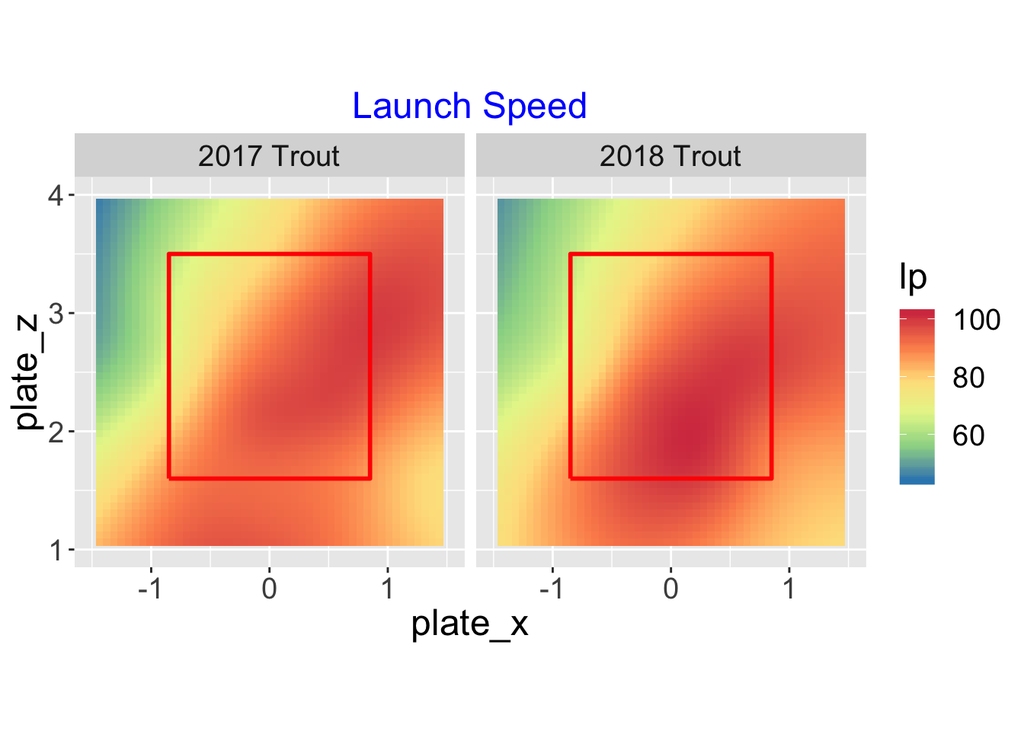

```r
compare_ip(mt_17, mt_18,
           "2017 Trout", "2018 Trout",
           type = "ls")
```

Compare home run probabilities for the two seasons:

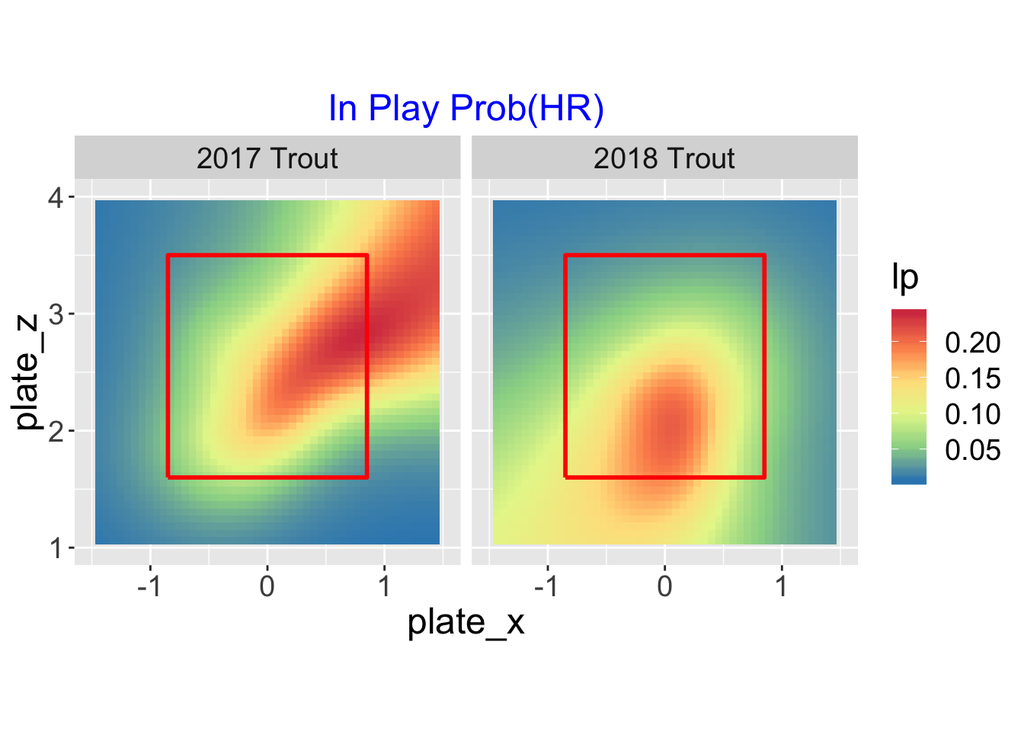

```r
compare_ip(mt_17, mt_18,
           "2017 Trout", "2018 Trout",
           type = "hr")
```

#### Comparison of Four Groups

There is also a special function for comparing four groups.

Also collect Trout statcast data for 2015 and 2016;

```r
mt_15 <- get_sc_data(mt_id, season = 2015)
mt_16 <- get_sc_data(mt_id, season = 2016)
```

Put the four data frames in a list and add names.

```r
mtdata <- list(mt_15, mt_16, mt_17, mt_18)
names(mtdata) <- paste("Trout", 2015:2018, sep= " ")
```

Now we can use the function compare_ip4():

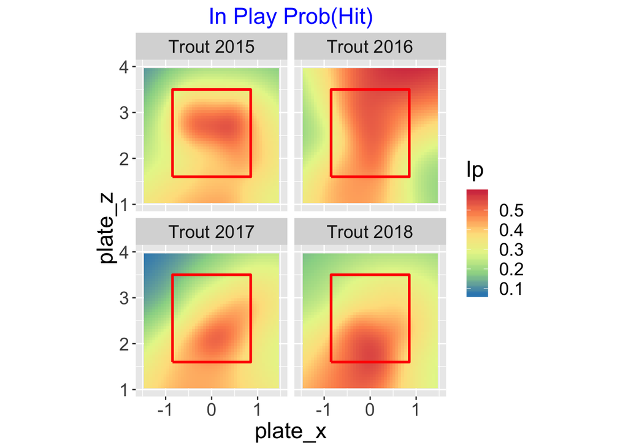

```r
compare_ip4(mtdata, type = "h")
```